# Bike trip preferences

theme: jekyll-theme-minimal

2023-08-14

## Plan

- Business task
- Description of the data
- Data preparation
- Analysis
- Key findings
- Recommendations

## Business task How do annual members and casual riders use Cyclistic bikes differently?

## Description of the data

I used Cyclistic’s historical trip data for the last 12 months. After I combined all 12 files together and cleaned the data from personal information, I got a big data file, containing  
5 779 444 rows and 9 columns:

- ride_id - special ride id number
- rideable_type - type of bike
- started_at - start trip time
- ended_at - end trip time
- start_station_name - name of start trip station
- start_station_id - special id of start trip station
- end_station_name - name of end trip station
- end_station_id - special id of end trip station
- member_casual - type of users

## Data preparation

The most important for me was to figure out what’s the difference in trips between membership holders and casual users.  
First of all, I checked that there are only two types of membership (member or casual), as it is supposed to be.  
Then I split the time data into several columns - such as day, month, and year - that provide more opportunities to aggregate the data.

## Some calculations

I decided to add a calculated field for the length of the ride (in minutes) for future comparisons.  
After that, I cleaned this data so it would be numeric (for future calculations) and credible.  
Let’s have a look at the mean, median, min, and max values of the trip’s length.

```
##     Min.  1st Qu.   Median     Mean  3rd Qu.     Max.
##     0.00     5.72    10.00    16.05    17.85 32035.45
```

## But it is more informative for us to have a look at this information, divided by membership holders and casual users.

## Mean and Median

Mean

```
##   all_trips_v2$member_casual all_trips_v2$ride_length_min
## 1                     casual                     22.49666
## 2                     member                     12.10124
```

Median

```
##   all_trips_v2$member_casual all_trips_v2$ride_length_min
## 1                     casual                    12.850000
## 2                     member                     8.666667
```

As we can see, in both cases (mean and median) casual users’ rides are longer than membership holders’.

## Max and Min

Max

```
##   all_trips_v2$member_casual all_trips_v2$ride_length_min
## 1                     casual                    32035.450
## 2                     member                     1497.867
```

Min

```
##   all_trips_v2$member_casual all_trips_v2$ride_length_min
## 1                     casual                            0
## 2                     member                            0
```

## Analysis

Let’s prepare a small dataset for further analysis.  
We will use information about the number of rides and average duration of trips per day of the week, grouped by our 2 categories: membership holders and casual users.  
Let’s have a look at our new dataset.

## Data subset

| member_casual | weekday | number_of_rides | average_duration |
| --- | --- | --- | --- |
| casual | Sun | 267191 | 25.76189 |
| casual | Mon | 189316 | 22.49960 |
| casual | Tue | 190148 | 19.96077 |
| casual | Wed | 204943 | 19.37181 |
| casual | Thu | 219864 | 19.69313 |
| casual | Fri | 254726 | 21.70055 |
| casual | Sat | 349415 | 25.55547 |
| member | Sun | 295398 | 13.42435 |
| member | Mon | 376537 | 11.53682 |
| member | Tue | 432668 | 11.53241 |

[output cut: 4 more lines]

## Let’s visualize the number of rides by rider type

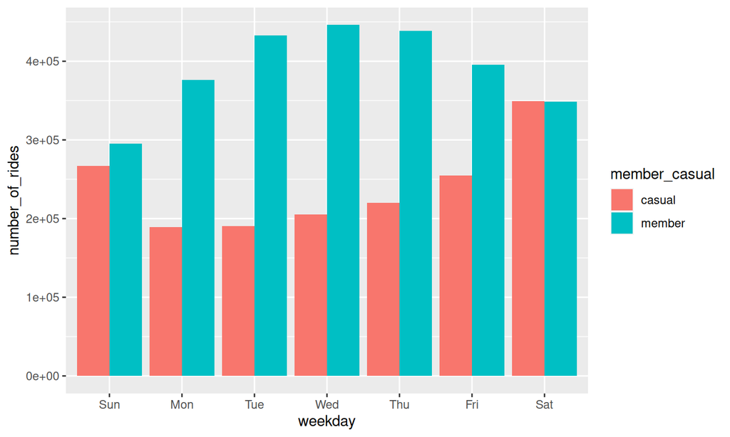

## Visualization for the average duration (in minutes)

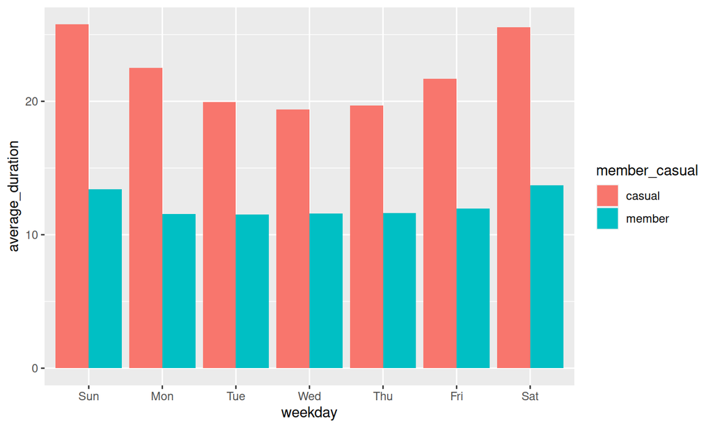

## Total amount of time (total = average duration * number of rides, in hours)

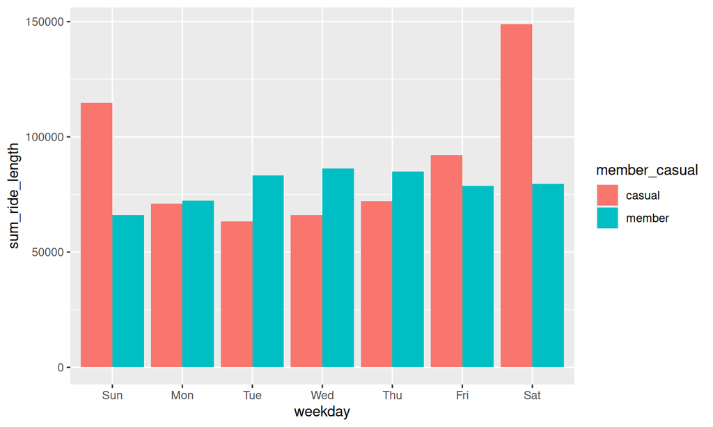

## Conclusions

During working days membership holders have twice more trips, but they are shorter than casual users’ (also twice).

If we look at the plot with summary duration for both categories, we can see, that on Monday-Friday membership holders and casual users spent the same amount of time on their trips.

But on Saturday-Sunday casual customers spend much more time (twice more) on their trips.

## New data subset

Let’s prepare a new dataset.  
We will also use information about the number of rides and average duration of trips, but this time we want to analyze changes during the year, grouped by our 2 categories: membership holders and casual users.  
Let’s have a look at our new dataset.

## Data subset (for casual users)

| member_casual | month | number_of_rides | average_duration |
| --- | --- | --- | --- |
| casual | 01 | 29621 | 14.87888 |
| casual | 02 | 32776 | 17.67230 |
| casual | 03 | 46792 | 16.71918 |
| casual | 04 | 110537 | 22.62086 |
| casual | 05 | 177037 | 24.52475 |
| casual | 06 | 219803 | 24.07359 |
| casual | 07 | 311670 | 25.09333 |
| casual | 08 | 270089 | 23.28440 |
| casual | 09 | 220913 | 21.80400 |
| casual | 10 | 151324 | 20.46782 |

[output cut: 2 more lines]

## Data subset (for membership holders)

| member_casual | month | number_of_rides | average_duration |
| --- | --- | --- | --- |
| member | 01 | 118663 | 10.00448 |
| member | 02 | 116784 | 10.42200 |
| member | 03 | 153655 | 10.17087 |
| member | 04 | 213657 | 11.55596 |
| member | 05 | 286185 | 12.69381 |
| member | 06 | 314962 | 12.94459 |
| member | 07 | 330996 | 13.50329 |
| member | 08 | 335224 | 13.10607 |
| member | 09 | 314227 | 12.62197 |
| member | 10 | 262943 | 11.67493 |

[output cut: 2 more lines]

## And let’s have a look of our new plots

Number of rides

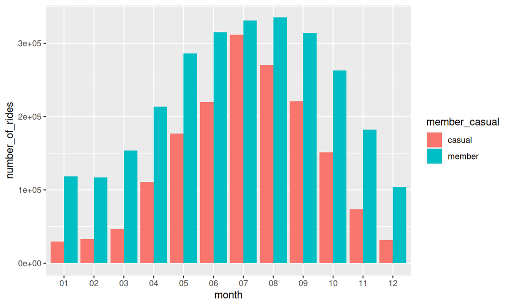

## Average duration (in minutes)

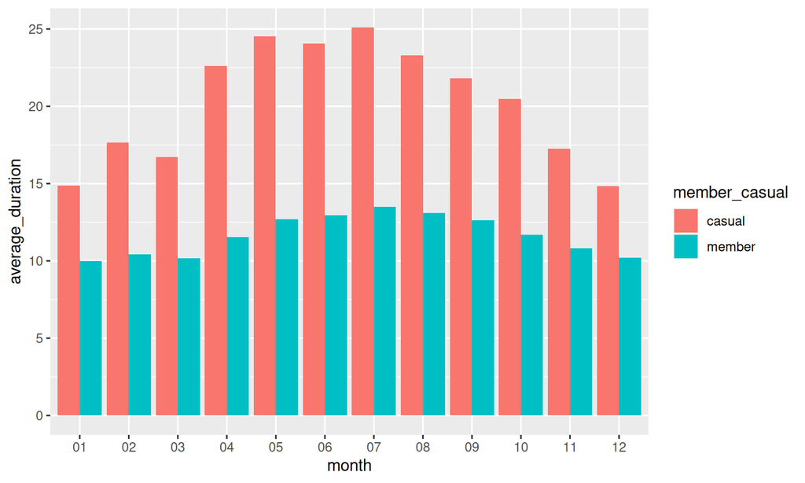

## Total amount of time (total = average duration * number of rides, in hours)

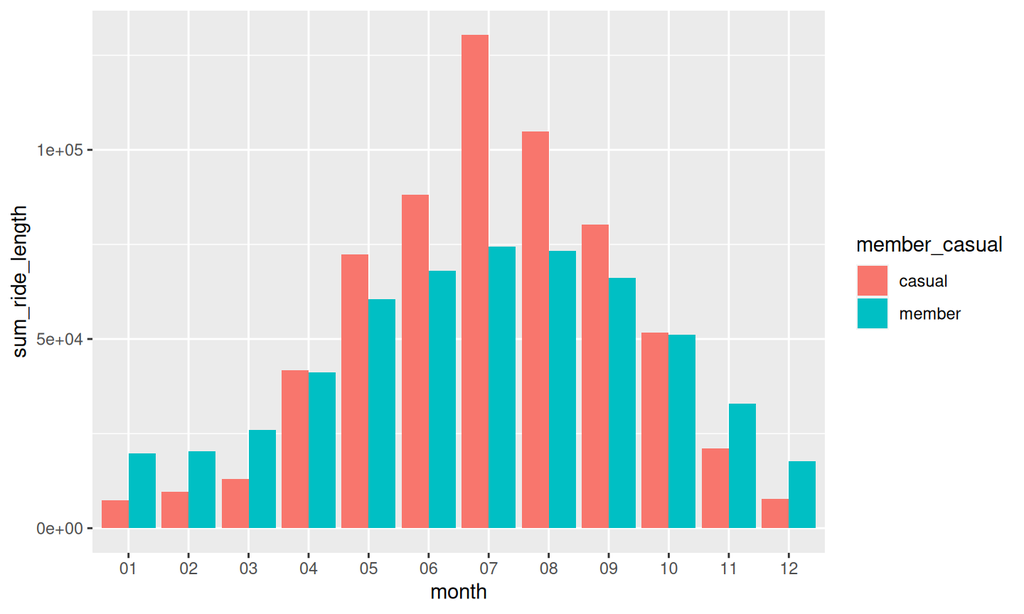

## Conclusions

Statistics during the year look similar for both categories (they both have more trips in summer).

## Final dataset

Finally, I decided to combine all my findings and prepare one dataset with information about our users, divided by months and type of day (weekday or weekend), so we can have a look at our results in one slide.

This time we need just information about the average trip duration because the number of rides and total trip time will not provide useful information.

## Average duration (in minutes)

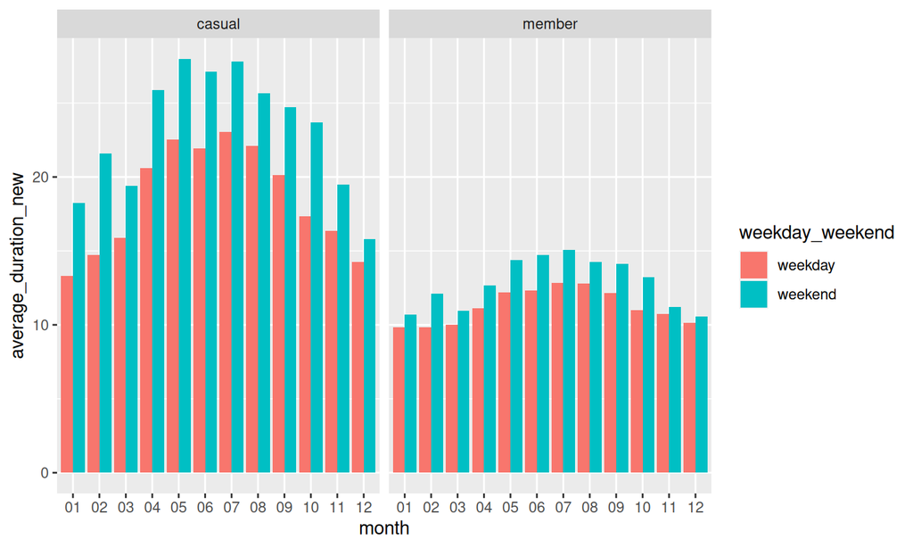

## Conclusions

Here we can see that casual users ride more on weekends during the whole year, and their rides increase in the summer period.

Membership holders on the other hand use bikes more stable during the whole year, regardless of the day of the week.

While membership holders use bikes as a transport to get to work or to the store (since their trips are shorter, but more regular every day during the whole year).

## Recommendations

I think it will be a great strategy to prepare a special membership option for only the weekend (for the whole year).

And returning to our year statistics, we can conclude, that the half-year membership (for the warm months: April-October) also would be a great decision.